# Telecom Customer Churn Analysis and Prediction

This project is a simple demonstration on how to implement machine learning in R. The dataset used for this dataset is obtained from the UC Irvine Machine Learning Repository named **[Iranian Churn Dataset](https://archive.ics.uci.edu/dataset/563/iranian+churn+dataset)**. The goal is to do binary classification to predict churn of telecom company. This prediction is useful to see the percentage of customer to discontinue in using the telecom services. If it the customer is labeled as churn, then the customer is likely to stop using the service.

# A. Data Wrangling

## 1. Data Exploration

### a. Opening The Dataset

```r
df <- read.csv('customer_churn.csv')
print(df)
```

| Call..Failure | Complains | Subscription..Length | Charge..Amount | Seconds.of.Use | Frequency.of.use | Frequency.of.SMS | Distinct.Called.Numbers | Age.Group | Tariff.Plan | Status | Age | Customer.Value | Churn |
| --- | --- | --- | --- | --- | --- | --- | --- | --- | --- | --- | --- | --- | --- |
| 8 | 0 | 38 | 0 | 4370 | 71 | 5 | 17 | 3 | 1 | 1 | 30 | 197.640 | 0 |
| 0 | 0 | 39 | 0 | 318 | 5 | 7 | 4 | 2 | 1 | 2 | 25 | 46.035 | 0 |
| 10 | 0 | 37 | 0 | 2453 | 60 | 359 | 24 | 3 | 1 | 1 | 30 | 1536.520 | 0 |
| 10 | 0 | 38 | 0 | 4198 | 66 | 1 | 35 | 1 | 1 | 1 | 15 | 240.020 | 0 |
| 3 | 0 | 38 | 0 | 2393 | 58 | 2 | 33 | 1 | 1 | 1 | 15 | 145.805 | 0 |
| 11 | 0 | 38 | 1 | 3775 | 82 | 32 | 28 | 3 | 1 | 1 | 30 | 282.280 | 0 |
| 4 | 0 | 38 | 0 | 2360 | 39 | 285 | 18 | 3 | 1 | 1 | 30 | 1235.960 | 0 |
| 13 | 0 | 37 | 2 | 9115 | 121 | 144 | 43 | 3 | 1 | 1 | 30 | 945.440 | 0 |
| 7 | 0 | 38 | 0 | 13773 | 169 | 0 | 44 | 3 | 1 | 1 | 30 | 557.680 | 0 |
| 7 | 0 | 38 | 1 | 4515 | 83 | 2 | 25 | 3 | 1 | 1 | 30 | 191.920 | 0 |

[output cut: 990 more lines]

There are several features in the dataset. From the [dataset’s source](https://archive.ics.uci.edu/ml/datasets/Iranian+Churn+Dataset), the features represents:

- **Call Failure**: number of call failures
- **Complains**: binary categorical where 0 = no complaint and 1 = complaint
- **Subscription Length**: total months of subscription
- **Charge Amount** = ordinal attribute in range 0 to 9 where 0 = lowest amount and 9 = highest amount
- **Seconds of Use** = total seconds of calls
- **Frequency of use** = total number of of calls
- **Frequency of SMS** = total number of text messages
- **Distinct Called Numbers** = total number of distinct phone calls
- **Age Group** = ordinal attribute in range 1 to 5 where 1 = younger age and 5 = older age
- **Tariff Plan** = binary categorical where 1 = pay as you go and 2 = contractual
- **Status** = binary categorical where 1 = active and 2 = non-active
- **Age** = actual age of the customer
- **Customer Value** = calculated value of customer
- **Churn** = binary categorical where 1 = churn and 0 = non-churn

The class label (Y) is the feature ‘Churn’ where the others are the feature for predicting the churn.

## 2. Data Cleaning

### a. Handling Missing Value

Checking the missing value

```r
sapply(df, function(x) sum(x=="" | is.na(x)))
```

```
          Call..Failure               Complains    Subscription..Length          Charge..Amount
                      0                       0                       0                       0
         Seconds.of.Use        Frequency.of.use        Frequency.of.SMS Distinct.Called.Numbers
                      0                       0                       0                       0
              Age.Group             Tariff.Plan                  Status                     Age
                      0                       0                       0                       0
         Customer.Value                   Churn
                      0                       0
```

Apparently there is no missing value found. Even so, checking for the unique value in from each features is considered as a good practice to recognize unrelated value to the purpose of the features. If found, then the unrelated value can be considered as missing value.

Checking for unique value from each features

```r
lapply(df, unique)
```

```
$Call..Failure
 [1]  8  0 10  3 11  4 13  7  6  9 25  2 23 21  1 16 12 14 28  5 26 24 19 15 22 20 18 17 30 27 29 31 33 35 32 34 36

$Complains
[1] 0 1

$Subscription..Length
 [1] 38 39 37 33 36 34 35 31 27 26 25 18 17 15 16  9 40 41 29 28 20 19 11 32 24 23 13 14  7 42 43 30 22 21 12  5 44 45
[39] 10  3  6  8  4 46 47

$Charge..Amount
 [1]  0  1  2  3  8  4  9  7  5 10  6

$Seconds.of.Use
   [1]  4370   318  2453  4198  2393  3775  2360  9115 13773  4515  5918  2238 15140  3095 15485  6500   875   710
```

[output cut: 191 more lines]

At a glance, there seems to be no unrelated value found.

### b. Handling Inconsistent Format

Checking for features’s data type

```r
sapply(df, class)
```

```
          Call..Failure               Complains    Subscription..Length          Charge..Amount
              "integer"               "integer"               "integer"               "integer"
         Seconds.of.Use        Frequency.of.use        Frequency.of.SMS Distinct.Called.Numbers
              "integer"               "integer"               "integer"               "integer"
              Age.Group             Tariff.Plan                  Status                     Age
              "integer"               "integer"               "integer"               "integer"
         Customer.Value                   Churn
              "numeric"               "integer"
```

Apparently all the features except ‘Customer.Value’ have integer data. The feature ‘Customer Value’ has numeric data type in double. All the features’ data type have fit the feature’s purpose.

Checking the number of category for categorical features

```r
print("Number of unique value on each features:")
```

```
[1] "Number of unique value on each features:"
```

```r
sapply(df, function(x) length(unique(x)))
```

```
          Call..Failure               Complains    Subscription..Length          Charge..Amount
                     37                       2                      45                      11
         Seconds.of.Use        Frequency.of.use        Frequency.of.SMS Distinct.Called.Numbers
                   1756                     242                     405                      92
              Age.Group             Tariff.Plan                  Status                     Age
                      5                       2                       2                       5
         Customer.Value                   Churn
                   2654                       2
```

- Feature ‘Charge’ should have 2 unique values (0 = no complaint and 1 = complaint). As the unique value of this feature is 2, thus it is consistent.
- Feature ‘Charge Amount’ should have 10 values (0 = lowest amount to 9 = highest amount). As the unique value of this feature is 11, thus it is inconsistent.

```r
# Checking for the unique value in feature 'Charge Amount'
print("Unique value in 'Charge Amount':")
```

```
[1] "Unique value in 'Charge Amount':"
```

```r
print(unique(df$Charge..Amount))
```

```
 [1]  0  1  2  3  8  4  9  7  5 10  6
```

```r
# Apparently, there is value '10'
# Checking the percentage of data contains value '10'

contains_val_10 = sapply(df, function(x) sum(x == 10)) / nrow(df) * 100
print(paste("% of value 10 in feature 'Charge Amount': ", contains_val_10["Charge..Amount"]))
```

```
[1] "% of value 10 in feature 'Charge Amount':  0.222222222222222"
```

As the data with value 10 in feature ‘Charge Amount’ is only contains 0.2%, the data with value 10 in feature ‘Charge Amount’ will be removed from dataset.

```r
df <- df[df[, "Charge..Amount"] != 10, ]

df
```

|  | Call..Failure | Complains | Subscription..Length | Charge..Amount | Seconds.of.Use | Frequency.of.use | Frequency.of.SMS | Distinct.Called.Numbers | Age.Group | Tariff.Plan | Status | Age | Customer.Value | Churn |
| --- | --- | --- | --- | --- | --- | --- | --- | --- | --- | --- | --- | --- | --- | --- |
| 1 | 8 | 0 | 38 | 0 | 4370 | 71 | 5 | 17 | 3 | 1 | 1 | 30 | 197.640 | 0 |
| 2 | 0 | 0 | 39 | 0 | 318 | 5 | 7 | 4 | 2 | 1 | 2 | 25 | 46.035 | 0 |
| 3 | 10 | 0 | 37 | 0 | 2453 | 60 | 359 | 24 | 3 | 1 | 1 | 30 | 1536.520 | 0 |
| 4 | 10 | 0 | 38 | 0 | 4198 | 66 | 1 | 35 | 1 | 1 | 1 | 15 | 240.020 | 0 |
| 5 | 3 | 0 | 38 | 0 | 2393 | 58 | 2 | 33 | 1 | 1 | 1 | 15 | 145.805 | 0 |
| 6 | 11 | 0 | 38 | 1 | 3775 | 82 | 32 | 28 | 3 | 1 | 1 | 30 | 282.280 | 0 |
| 7 | 4 | 0 | 38 | 0 | 2360 | 39 | 285 | 18 | 3 | 1 | 1 | 30 | 1235.960 | 0 |
| 8 | 13 | 0 | 37 | 2 | 9115 | 121 | 144 | 43 | 3 | 1 | 1 | 30 | 945.440 | 0 |
| 9 | 7 | 0 | 38 | 0 | 13773 | 169 | 0 | 44 | 3 | 1 | 1 | 30 | 557.680 | 0 |
| 10 | 7 | 0 | 38 | 1 | 4515 | 83 | 2 | 25 | 3 | 1 | 1 | 30 | 191.920 | 0 |

[output cut: 990 more lines]

Thus, the format is already consistent

### c. Handling Duplicate Data

Checking if there is duplicate data in the dataset

```r
dup <- duplicated(df)

df[dup, ]
```

|  | Call..Failure | Complains | Subscription..Length | Charge..Amount | Seconds.of.Use | Frequency.of.use | Frequency.of.SMS | Distinct.Called.Numbers | Age.Group | Tariff.Plan | Status | Age | Customer.Value | Churn |
| --- | --- | --- | --- | --- | --- | --- | --- | --- | --- | --- | --- | --- | --- | --- |
| 519 | 0 | 0 | 37 | 0 | 0 | 0 | 0 | 0 | 2 | 1 | 2 | 25 | 0.000 | 1 |
| 629 | 0 | 0 | 35 | 0 | 0 | 0 | 0 | 0 | 2 | 1 | 2 | 25 | 0.000 | 1 |
| 719 | 0 | 0 | 37 | 0 | 0 | 0 | 0 | 0 | 2 | 1 | 2 | 25 | 0.000 | 1 |
| 729 | 0 | 0 | 36 | 0 | 0 | 0 | 0 | 0 | 3 | 1 | 2 | 30 | 0.000 | 1 |
| 902 | 0 | 0 | 38 | 0 | 0 | 0 | 0 | 0 | 2 | 1 | 2 | 25 | 0.000 | 0 |
| 951 | 8 | 0 | 38 | 0 | 4370 | 71 | 5 | 17 | 3 | 1 | 1 | 30 | 197.640 | 0 |
| 952 | 0 | 0 | 39 | 0 | 318 | 5 | 7 | 4 | 2 | 1 | 2 | 25 | 46.035 | 0 |
| 953 | 10 | 0 | 37 | 0 | 2453 | 60 | 359 | 24 | 3 | 1 | 1 | 30 | 1536.520 | 0 |
| 954 | 10 | 0 | 38 | 0 | 4198 | 66 | 1 | 35 | 1 | 1 | 1 | 15 | 240.020 | 0 |
| 955 | 3 | 0 | 38 | 0 | 2393 | 58 | 2 | 33 | 1 | 1 | 1 | 15 | 145.805 | 0 |

[output cut: 290 more lines]

Apparently there are 300 duplicated data. Those data will be removed from the dataset.

```r
df <- unique(df)

df
```

|  | Call..Failure | Complains | Subscription..Length | Charge..Amount | Seconds.of.Use | Frequency.of.use | Frequency.of.SMS | Distinct.Called.Numbers | Age.Group | Tariff.Plan | Status | Age | Customer.Value | Churn |
| --- | --- | --- | --- | --- | --- | --- | --- | --- | --- | --- | --- | --- | --- | --- |
| 1 | 8 | 0 | 38 | 0 | 4370 | 71 | 5 | 17 | 3 | 1 | 1 | 30 | 197.640 | 0 |
| 2 | 0 | 0 | 39 | 0 | 318 | 5 | 7 | 4 | 2 | 1 | 2 | 25 | 46.035 | 0 |
| 3 | 10 | 0 | 37 | 0 | 2453 | 60 | 359 | 24 | 3 | 1 | 1 | 30 | 1536.520 | 0 |
| 4 | 10 | 0 | 38 | 0 | 4198 | 66 | 1 | 35 | 1 | 1 | 1 | 15 | 240.020 | 0 |
| 5 | 3 | 0 | 38 | 0 | 2393 | 58 | 2 | 33 | 1 | 1 | 1 | 15 | 145.805 | 0 |
| 6 | 11 | 0 | 38 | 1 | 3775 | 82 | 32 | 28 | 3 | 1 | 1 | 30 | 282.280 | 0 |
| 7 | 4 | 0 | 38 | 0 | 2360 | 39 | 285 | 18 | 3 | 1 | 1 | 30 | 1235.960 | 0 |
| 8 | 13 | 0 | 37 | 2 | 9115 | 121 | 144 | 43 | 3 | 1 | 1 | 30 | 945.440 | 0 |
| 9 | 7 | 0 | 38 | 0 | 13773 | 169 | 0 | 44 | 3 | 1 | 1 | 30 | 557.680 | 0 |
| 10 | 7 | 0 | 38 | 1 | 4515 | 83 | 2 | 25 | 3 | 1 | 1 | 30 | 191.920 | 0 |

[output cut: 990 more lines]

## 2. Data Analysis and Feature Engineering

### a. Handling Imbalanced Data

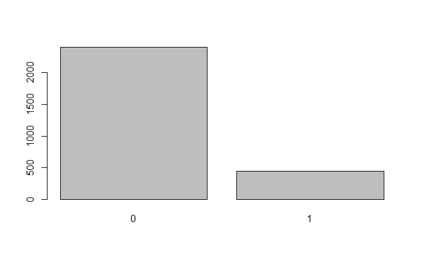

```r
label_val_ctr = table(df[, "Churn"])
percentages <- prop.table(label_val_ctr) * 100

barplot(label_val_ctr, names.arg = names(label_val_ctr))
```

### b. Feature Selection

Checking the correlation of features with the label ‘Churn’

```r
corr_label = cor(df[, "Churn"], df)

corr_label
```

```
     Call..Failure Complains Subscription..Length Charge..Amount Seconds.of.Use Frequency.of.use Frequency.of.SMS
[1,]   0.006339147 0.5475677          -0.03706504     -0.2042391     -0.2952969       -0.2981718       -0.2195039
     Distinct.Called.Numbers    Age.Group Tariff.Plan   Status          Age Customer.Value Churn
[1,]              -0.2695866 -0.003345756  -0.1049605 0.492575 -0.008708387     -0.2878184     1
```

Sorting the correlation (absolute) of features

```r
sorted_idx_corr <- order(abs(corr_label), decreasing = TRUE)
sorted_corr <- corr_label[sorted_idx_corr]
sorted_features_corr <- names(df)[sorted_idx_corr]

data.frame(features = sorted_features_corr, correlation = sorted_corr)
```

| features | correlation |
| --- | --- |
| Churn | 1.000000000 |
| Complains | 0.547567704 |
| Status | 0.492575019 |
| Frequency.of.use | -0.298171778 |
| Seconds.of.Use | -0.295296904 |
| Customer.Value | -0.287818362 |
| Distinct.Called.Numbers | -0.269586638 |
| Frequency.of.SMS | -0.219503860 |
| Charge..Amount | -0.204239088 |
| Tariff.Plan | -0.104960469 |

[output cut: 4 more lines]

- It seems like only feature ‘Complains’ and ‘Status’ have moderate correlation
- Feature ‘Frequency of use’, ‘Seconds of Use’, ‘Customer Value’, ‘Distinct Called Numbers’, ‘Frequency of SMS’, and ‘Charge Amount’ have low correlation

The prediction will be focusing on those features with moderate correlation and low correlation. Thus, the irrelevant features will be dropped.

```r
irrelevant_feature <- colnames(corr_label)[apply(abs(corr_label) < 0.2, 2, any)]

df <- df[, !names(df) %in% irrelevant_feature]
print(df)
```

|  | Complains | Charge..Amount | Seconds.of.Use | Frequency.of.use | Frequency.of.SMS | Distinct.Called.Numbers | Status | Customer.Value | Churn |
| --- | --- | --- | --- | --- | --- | --- | --- | --- | --- |
| 1 | 0 | 0 | 4370 | 71 | 5 | 17 | 1 | 197.640 | 0 |
| 2 | 0 | 0 | 318 | 5 | 7 | 4 | 2 | 46.035 | 0 |
| 3 | 0 | 0 | 2453 | 60 | 359 | 24 | 1 | 1536.520 | 0 |
| 4 | 0 | 0 | 4198 | 66 | 1 | 35 | 1 | 240.020 | 0 |
| 5 | 0 | 0 | 2393 | 58 | 2 | 33 | 1 | 145.805 | 0 |
| 6 | 0 | 1 | 3775 | 82 | 32 | 28 | 1 | 282.280 | 0 |
| 7 | 0 | 0 | 2360 | 39 | 285 | 18 | 1 | 1235.960 | 0 |
| 8 | 0 | 2 | 9115 | 121 | 144 | 43 | 1 | 945.440 | 0 |
| 9 | 0 | 0 | 13773 | 169 | 0 | 44 | 1 | 557.680 | 0 |
| 10 | 0 | 1 | 4515 | 83 | 2 | 25 | 1 | 191.920 | 0 |

[output cut: 990 more lines]

### c. Handling Outlier

Check the feature data condition

```r
summary(df)
```

```
   Complains       Charge..Amount   Seconds.of.Use  Frequency.of.use Frequency.of.SMS Distinct.Called.Numbers
 Min.   :0.00000   Min.   :0.0000   Min.   :    0   Min.   :  0.0    Min.   :  0.00   Min.   : 0.00
 1st Qu.:0.00000   1st Qu.:0.0000   1st Qu.: 1453   1st Qu.: 28.0    1st Qu.:  7.00   1st Qu.:11.00
 Median :0.00000   Median :0.0000   Median : 3035   Median : 54.0    Median : 22.00   Median :21.00
 Mean   :0.08055   Mean   :0.9525   Mean   : 4518   Mean   : 70.4    Mean   : 73.92   Mean   :23.81
 3rd Qu.:0.00000   3rd Qu.:1.0000   3rd Qu.: 6482   3rd Qu.: 95.0    3rd Qu.: 89.00   3rd Qu.:34.00
 Max.   :1.00000   Max.   :9.0000   Max.   :17090   Max.   :255.0    Max.   :522.00   Max.   :97.00
     Status      Customer.Value       Churn
 Min.   :1.000   Min.   :   0.0   Min.   :0.0000
 1st Qu.:1.000   1st Qu.: 117.3   1st Qu.:0.0000
 Median :1.000   Median : 233.2   Median :0.0000
 Mean   :1.241   Mean   : 475.7   Mean   :0.1569
 3rd Qu.:1.000   3rd Qu.: 791.1   3rd Qu.:0.0000
 Max.   :2.000   Max.   :2165.3   Max.   :1.0000
```

Plotting the boxplot to see the outliers for more accurate

```r
plot_boxplot <- function(df){
  par(mfrow = c(2, 5))
  for (col in names(df)) {
    boxplot(df[[col]], main = col, ylab = col)
  }
}
```

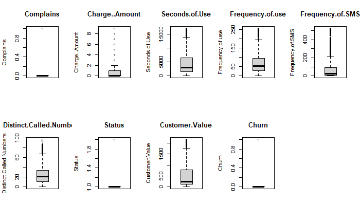

```r
plot_boxplot(df)
```

To maintain the information, the outliers will be handled by changing the outlier value to upper extreme or lower extreme.

```r
handle_outlier <- function(df, features){
  for (col in features){
    data <- df[[col]]

    q <- quantile(data, probs=c(0.25, 0.75), na.rm = T)

    iqr <- 1.5 * IQR(data, na.rm = T)

    lower_ext = q[1] - iqr
    upper_ext = q[2] + iqr

    data[data < lower_ext] <- lower_ext
    data[data > upper_ext] <- upper_ext


    df[[col]] <- data
  }

  return (df)
}
```

```r
feature_out_handle <- c("Charge..Amount", "Seconds.of.Use", "Frequency.of.use", "Frequency.of.SMS", "Distinct.Called.Numbers", "Customer.Value")

df <- handle_outlier(df, feature_out_handle)
```

Get the features summary and re-plotting to see the boxplot after handling the outliers

```r
summary(df)
```

```
   Complains       Charge..Amount   Seconds.of.Use  Frequency.of.use Frequency.of.SMS Distinct.Called.Numbers
 Min.   :0.00000   Min.   :0.0000   Min.   :    0   Min.   :  0.00   Min.   :  0.00   Min.   : 0.00
 1st Qu.:0.00000   1st Qu.:0.0000   1st Qu.: 1453   1st Qu.: 28.00   1st Qu.:  7.00   1st Qu.:11.00
 Median :0.00000   Median :0.0000   Median : 3035   Median : 54.00   Median : 22.00   Median :21.00
 Mean   :0.08055   Mean   :0.7564   Mean   : 4422   Mean   : 68.91   Mean   : 59.35   Mean   :23.53
 3rd Qu.:0.00000   3rd Qu.:1.0000   3rd Qu.: 6482   3rd Qu.: 95.00   3rd Qu.: 89.00   3rd Qu.:34.00
 Max.   :1.00000   Max.   :2.5000   Max.   :14024   Max.   :195.50   Max.   :212.00   Max.   :68.50
     Status      Customer.Value       Churn
 Min.   :1.000   Min.   :   0.0   Min.   :0.0000
 1st Qu.:1.000   1st Qu.: 117.3   1st Qu.:0.0000
 Median :1.000   Median : 233.2   Median :0.0000
 Mean   :1.241   Mean   : 468.5   Mean   :0.1569
 3rd Qu.:1.000   3rd Qu.: 791.1   3rd Qu.:0.0000
 Max.   :2.000   Max.   :1801.6   Max.   :1.0000
```

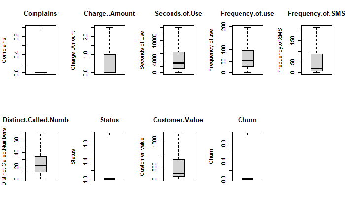

```r
plot_boxplot(df)
```

### d. Split Dataset into Train and Test Set

```r
df$Churn <- as.factor(df$Churn)
df$Churn <- as.factor(ifelse(df$Churn == "0", "nonchurn", "churn"))

set.seed(125)
train_idx <- createDataPartition(df$Churn, p=0.8, list = FALSE)

df_test <- df[-train_idx, ]
df_train <- df[train_idx, ]
```

# C. Training Model

Do the 5-folds cross-validation. Metric ROC is used due to the imbalanced data based on the label ‘Churn’ as shown in the feature engineering step.

```r
control <- trainControl(method = "cv", number = 5, classProbs=TRUE, summaryFunction=twoClassSummary)
metric <- "ROC"
```

## 1 Initialize Model

### a. Random Forest

```r
rf_model <- train(Churn~., data = df_train, method = "rf", metric = metric, trControl = control)

rf_model
```

```
Random Forest

2275 samples
   8 predictor
   2 classes: 'churn', 'nonchurn'

No pre-processing
Resampling: Cross-Validated (5 fold)
Summary of sample sizes: 1821, 1820, 1820, 1819, 1820
Resampling results across tuning parameters:

  mtry  ROC        Sens       Spec
  2     0.9583140  0.6384977  0.9739284
  5     0.9536320  0.6860720  0.9661118
  8     0.9491206  0.6803991  0.9676784

ROC was used to select the optimal model using the largest value.
The final value used for the model was mtry = 2.
```

The best parameter for Random Forest on this case based on the ROC is using 2 features to consider at each split point (mtry).

### b. Regularized Logistic Regression

```r
reglog_model <- train(Churn~., data = df_train, method = "regLogistic", metric = metric, trControl = control)

reglog_model
```

```
Regularized Logistic Regression

2275 samples
   8 predictor
   2 classes: 'churn', 'nonchurn'

No pre-processing
Resampling: Cross-Validated (5 fold)
Summary of sample sizes: 1820, 1819, 1819, 1821, 1821
Resampling results across tuning parameters:

  cost  loss       epsilon  ROC        Sens        Spec
  0.5   L1         0.001    0.9135615  0.41776213  0.9859225
  0.5   L1         0.010    0.9117445  0.41776213  0.9890475
  0.5   L1         0.100    0.9044988  0.41212833  0.9921807
  0.5   L2_dual    0.001    0.7199603  0.29491393  0.7968845
  0.5   L2_dual    0.010    0.8365966  0.13431142  0.9890503
  0.5   L2_dual    0.100    0.7348588  0.27793427  0.8109280
  0.5   L2_primal  0.001    0.8135912  0.09796557  0.9827989
  0.5   L2_primal  0.010    0.8113768  0.09796557  0.9827989
  0.5   L2_primal  0.100    0.8008122  0.06150235  0.9963474
  1.0   L1         0.001    0.9158885  0.41212833  0.9890557
  1.0   L1         0.010    0.9096003  0.40649452  0.9921807
  1.0   L1         0.100    0.9041659  0.40931142  0.9921807
  1.0   L2_dual    0.001    0.8308358  0.14542254  0.9880086
  1.0   L2_dual    0.010    0.8275846  0.16760563  0.9713025
  1.0   L2_dual    0.100    0.7157156  0.28086854  0.8083211
  1.0   L2_primal  0.001    0.8135912  0.09796557  0.9827989
  1.0   L2_primal  0.010    0.8113768  0.09796557  0.9827989
  1.0   L2_primal  0.100    0.8008122  0.06150235  0.9963474
  2.0   L1         0.001    0.9161672  0.42339593  0.9859225
  2.0   L1         0.010    0.9080242  0.41494523  0.9916585
  2.0   L1         0.100    0.9049035  0.40931142  0.9921807
  2.0   L2_dual    0.001    0.8184110  0.15109546  0.9587739
  2.0   L2_dual    0.010    0.8479410  0.21294992  0.9723578
  2.0   L2_dual    0.100    0.6107578  0.48039906  0.6350169
  2.0   L2_primal  0.001    0.8135912  0.09796557  0.9827989
  2.0   L2_primal  0.010    0.8113768  0.09796557  0.9827989
  2.0   L2_primal  0.100    0.8008122  0.06150235  0.9963474

ROC was used to select the optimal model using the largest value.
The final values used for the model were cost = 2, loss = L1 and epsilon = 0.001.
```

## 2. Evaluate Model

Get the best models

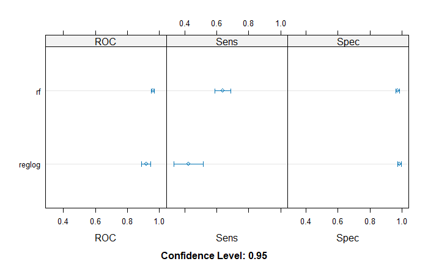

```r
results <- resamples(list(rf = rf_model, reglog = reglog_model))

dotplot(results)
```

From the result above, it appears that Random Forest is the most accurate model for the training set.

## 3. Model Prediction Model

Prediction using test set on Random Forest Model

```r
rf_pred <- predict(rf_model, df_test)

confusionMatrix(rf_pred, df_test$Churn)
```

```
Confusion Matrix and Statistics

          Reference
Prediction churn nonchurn
  churn       61        8
  nonchurn    28      471

               Accuracy : 0.9366
                 95% CI : (0.9133, 0.9552)
    No Information Rate : 0.8433
    P-Value [Acc > NIR] : 8.568e-12

                  Kappa : 0.736

 Mcnemar's Test P-Value : 0.001542

            Sensitivity : 0.6854
            Specificity : 0.9833
         Pos Pred Value : 0.8841
         Neg Pred Value : 0.9439
             Prevalence : 0.1567
         Detection Rate : 0.1074
   Detection Prevalence : 0.1215
      Balanced Accuracy : 0.8343

       'Positive' Class : churn
```

Prediction using test set on Regularized Logistic Regression

```r
reglog_pred <- predict(reglog_model, df_test)

confusionMatrix(reglog_pred, df_test$Churn)
```

```
Confusion Matrix and Statistics

          Reference
Prediction churn nonchurn
  churn       40        2
  nonchurn    49      477

               Accuracy : 0.9102
                 95% CI : (0.8836, 0.9324)
    No Information Rate : 0.8433
    P-Value [Acc > NIR] : 1.886e-06

                  Kappa : 0.5672

 Mcnemar's Test P-Value : 1.185e-10

            Sensitivity : 0.44944
            Specificity : 0.99582
         Pos Pred Value : 0.95238
         Neg Pred Value : 0.90684
             Prevalence : 0.15669
         Detection Rate : 0.07042
   Detection Prevalence : 0.07394
      Balanced Accuracy : 0.72263

       'Positive' Class : churn
```

From the result, Random Forest model has higher balanced accuracy with 0.8343 compared to Regularized Logistic Regression with 0.72263

# D. Conclusion

From the result, it is found that **Random Forest** gives better performance compared to Regularized Logistic Regression based on the ROC = 0.9583140 and balanced accuracy = 0.8343. The best parameter for the Random Forest mode on this dataset based on the ROC is using 2 features to consider at each split point (mtry).